# Unleashing the Power of Artificial Intelligence and Enzymatic Reaction Mechanisms for Drug Discovery

Harnessing cutting-edge technologies and understanding the intricate mechanisms behind enzymatic reactions are crucial for developing effective therapeutics in the rapidly evolving field of drug discovery. This groundbreaking study explores the potential of artificial intelligence technique in combination with the insights gained from enzymatic reaction mechanisms to revolutionize drug discovery. By integrating machine / deep learning algorithms with the knowledge of how enzymes catalyze chemical reactions, we aim to uncover hidden patterns and relationships within vast data sets, leading to the identification of novel drug candidates with enhanced precision and efficiency. This interdisciplinary approach holds immense promise for accelerating the development of life-saving medications and advancing the frontiers of personalized medicine. Through the groundbreaking synergy of deep learning and enzymatic reaction mechanisms, we expect to unleash a new era of drug discovery, where the power of artificial intelligence and biochemical insights converge to transform the pharmaceutical landscape.

**My research will focus on the applying AI and computer simulation in unpuzzling the mystery in drug developemnt and medical diagnosis.**

**1. Multi-scale molecular modeling and free energy calculations**

QM/MM hybrid potential with molecular dynamics simulations are adopted to exploit enzymatic reaction mechanism. Developing data mining algorithm to uncover the mechanisms for biological processes.

**2. Machine / Deep Learning for drug molecular property prediction**

Classical machine learning and deep learning methods are used to predict protein-ligand / protein-peptide binding free energy to increase virtual screening power in drug discovery.

**3. Deep de novo molecule generation**

Using generative ability to enumerate candidates or new lead compounds for drug discovery.

**4. Intelligent medical image analysis**

Developing novel deep learning methods for assisting diagnosis.

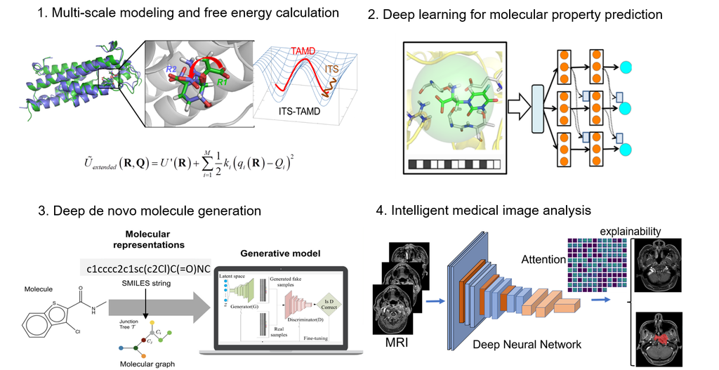

**Various computational tools are applied for elucidating processes of life science. Please find more details in each section.**

1. Enzymatic reaction mechanism.
2. Molecular representation for molecular property prediciton.
3. Multimodal deep learning.
4. de novo molecule genration.
5. Fragment contribution to binding affinity.
6. MD and ML for peptide design.
7. Medical image classification and segmentation.

*Return to Main Page*.